# Multi-Class Classification Model for Steel Plates Faults Using R

### 4.d) Generate models using ensemble algorithms

In this section, we will explore the use and tuning of ensemble algorithms to see whether we can improve the results.

```r
# Bagged CART (Regression/Classification)
startTimeModule <- proc.time()
set.seed(seedNum)
fit.bagcart <- train(targetVar~., data=training, method="treebag", metric=metricTarget, trControl=control)
proc.time()-startTimeModule
```

```
##    user  system elapsed
##   17.98    0.00   17.98
```

```r
# Random Forest (Regression/Classification)
startTimeModule <- proc.time()
set.seed(seedNum)
fit.rf <- train(targetVar~., data=training, method="rf", metric=metricTarget, trControl=control)
proc.time()-startTimeModule
```

```
##    user  system elapsed
##  130.59    0.69  132.39
```

```r
# Stochastic Gradient Boosting (Regression/Classification)
startTimeModule <- proc.time()
set.seed(seedNum)
fit.gbm <- train(targetVar~., data=training, method="gbm", metric=metricTarget, trControl=control, verbose=F)
proc.time()-startTimeModule
```

```
##    user  system elapsed
##  111.19    0.21  111.60
```

### 4.e) Compare baseline algorithms

```r
results <- resamples(list(LDA=fit.lda, CART=fit.cart, kNN=fit.knn, SVM=fit.svm, BagCART=fit.bagcart, RF=fit.rf, GBM=fit.gbm))
summary(results)
```

```
##
## Call:
## summary.resamples(object = results)
##
## Models: LDA, CART, kNN, SVM, BagCART, RF, GBM
## Number of resamples: 30
##
## Accuracy
##              Min.   1st Qu.    Median      Mean   3rd Qu.      Max. NA's
## LDA     0.6296296 0.6642336 0.6897810 0.6928831 0.7182367 0.7629630    0
## CART    0.5514706 0.5912409 0.6181900 0.6241326 0.6537718 0.7111111    0
## kNN     0.4233577 0.4740741 0.4853204 0.4933507 0.5136473 0.5839416    0
## SVM     0.6739130 0.7224265 0.7389835 0.7418864 0.7611111 0.8148148    0
## BagCART 0.6884058 0.7467385 0.7749183 0.7732102 0.8066176 0.8370370    0
## RF      0.7246377 0.7518248 0.7838933 0.7809892 0.8062855 0.8592593    0
## GBM     0.7205882 0.7486111 0.7703704 0.7722208 0.7937364 0.8444444    0
##
## Kappa
##              Min.   1st Qu.    Median      Mean   3rd Qu.      Max. NA's
## LDA     0.5291902 0.5755548 0.6046690 0.6072588 0.6418986 0.6984504    0
## CART    0.4010108 0.4603897 0.5023701 0.5016021 0.5428600 0.6158617    0
## kNN     0.2148712 0.2832064 0.3012899 0.3128768 0.3464110 0.4181507    0
## SVM     0.5705691 0.6385320 0.6599143 0.6646743 0.6869630 0.7608249    0
## BagCART 0.5930878 0.6722080 0.7060017 0.7052473 0.7496012 0.7890775    0
## RF      0.6384446 0.6772908 0.7192424 0.7150525 0.7481974 0.8176843    0
## GBM     0.6402799 0.6745760 0.6976513 0.7048999 0.7316063 0.7982781    0
```

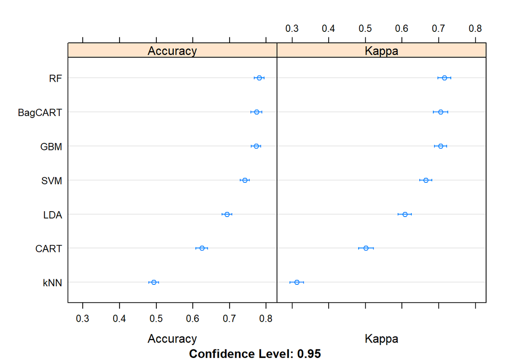

```r
dotplot(results)
```

## 5. Improve Accuracy or Results

After we achieve a short list of machine learning algorithms with good level of accuracy, we can leverage ways to improve the accuracy of the models.

Using the three best-perfoming algorithms from the previous section, we will Search for a combination of parameters for each algorithm that yields the best results.

### 5.a) Algorithm Tuning

Finally, we will tune the best-performing algorithms from each group further and see whether we can get more accuracy out of them.

```r
# Tuning algorithm #1 - Bagged CART
# Bagged CART does not use specialized tuning parameters
startTimeModule <- proc.time()
set.seed(seedNum)
fit.final1 <- fit.bagcart
print(fit.final1)
```

```
## Bagged CART
##
## 1362 samples
##   27 predictor
##    7 classes: '1', '2', '3', '4', '5', '6', '7'
##
## No pre-processing
## Resampling: Cross-Validated (10 fold, repeated 3 times)
## Summary of sample sizes: 1226, 1226, 1224, 1227, 1225, 1225, ...
## Resampling results:
##
##   Accuracy   Kappa
##   0.7732102  0.7052473
```

```r
proc.time()-startTimeModule
```

```
##    user  system elapsed
##    0.02    0.00    0.01
```

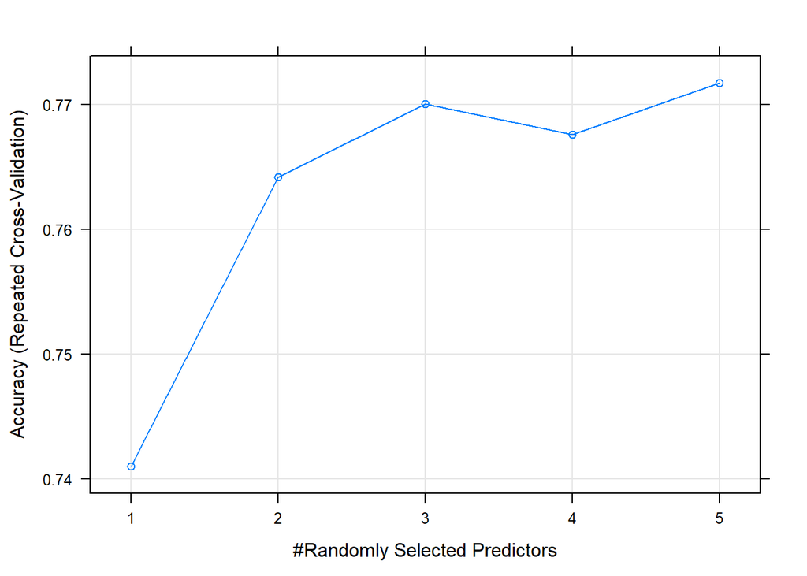

```r
# Tuning algorithm #2 - Random Forest
startTimeModule <- proc.time()
set.seed(seedNum)
grid <- expand.grid(mtry = c(1:5))
fit.final2 <- train(targetVar~., data=training, method="rf", metric=metricTarget, tuneGrid=grid, trControl=control)
plot(fit.final2)
```

```r
print(fit.final2)
```

```
## Random Forest
##
## 1362 samples
##   27 predictor
##    7 classes: '1', '2', '3', '4', '5', '6', '7'
##
## No pre-processing
## Resampling: Cross-Validated (10 fold, repeated 3 times)
## Summary of sample sizes: 1226, 1226, 1224, 1227, 1225, 1225, ...
## Resampling results across tuning parameters:
##
##   mtry  Accuracy   Kappa
##   1     0.7409836  0.6575956
##   2     0.7641929  0.6916357
##   3     0.7700543  0.6997523
##   4     0.7675908  0.6969540
##   5     0.7717631  0.7022535
##
## Accuracy was used to select the optimal model using the largest value.
## The final value used for the model was mtry = 5.
```

```r
proc.time()-startTimeModule
```

```
##    user  system elapsed
##  169.75    1.38  171.20
```

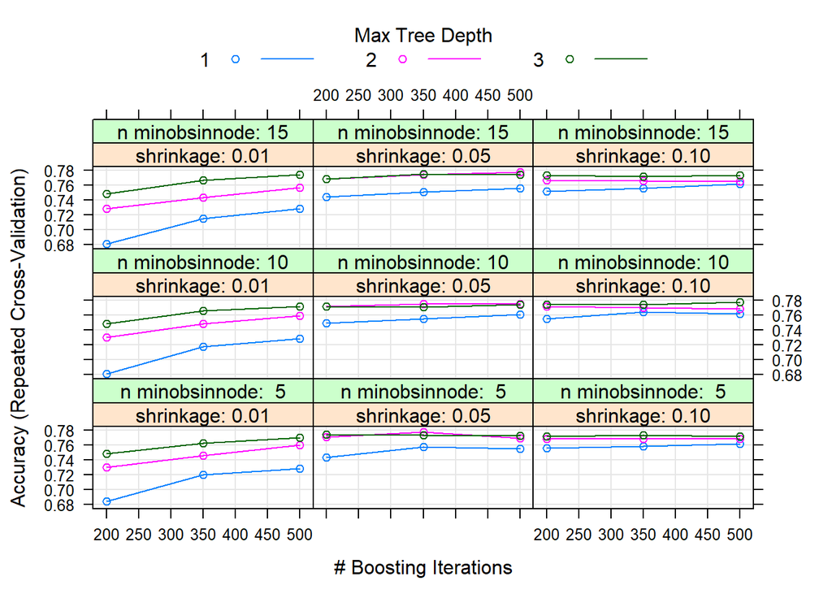

```r
# Tuning algorithm #3 - Stochastic Gradient Boosting
startTimeModule <- proc.time()
set.seed(seedNum)
grid <- expand.grid(.n.trees=c(200, 350, 500), .shrinkage=c(0.01, 0.05, 0.1), .interaction.depth=c(1, 2, 3), .n.minobsinnode=c(5, 10, 15))
fit.final3 <- train(targetVar~., data=training, method="gbm", metric=metricTarget, tuneGrid=grid, trControl=control, verbose=F)
plot(fit.final3)
```

```r
print(fit.final3)
```

```
## Stochastic Gradient Boosting
##
## 1362 samples
##   27 predictor
##    7 classes: '1', '2', '3', '4', '5', '6', '7'
##
## No pre-processing
## Resampling: Cross-Validated (10 fold, repeated 3 times)
## Summary of sample sizes: 1226, 1226, 1224, 1227, 1225, 1225, ...
## Resampling results across tuning parameters:
##
##   shrinkage  interaction.depth  n.minobsinnode  n.trees  Accuracy
##   0.01       1                   5              200      0.6838703
##   0.01       1                   5              350      0.7193448
##   0.01       1                   5              500      0.7281621
##   0.01       1                  10              200      0.6806801
##   0.01       1                  10              350      0.7171590
##   0.01       1                  10              500      0.7279295
##   0.01       1                  15              200      0.6804745
##   0.01       1                  15              350      0.7151780
##   0.01       1                  15              500      0.7281853
##   0.01       2                   5              200      0.7298814
##   0.01       2                   5              350      0.7455093
##   0.01       2                   5              500      0.7594394
##   0.01       2                  10              200      0.7299158
##   0.01       2                  10              350      0.7477603
##   0.01       2                  10              500      0.7589747
##   0.01       2                  15              200      0.7281602
##   0.01       2                  15              350      0.7435573
##   0.01       2                  15              500      0.7562726
##   0.01       3                   5              200      0.7480055
##   0.01       3                   5              350      0.7621715
##   0.01       3                   5              500      0.7697484
##   0.01       3                  10              200      0.7477443
##   0.01       3                  10              350      0.7655872
##   0.01       3                  10              500      0.7716949
##   0.01       3                  15              200      0.7480184
##   0.01       3                  15              350      0.7663473
##   0.01       3                  15              500      0.7739314
##   0.05       1                   5              200      0.7426199
```

[output cut: 124 more lines]

```
##   0.6967927
##   0.6955844
##   0.7040271
##   0.7065264
##   0.7031414
##   0.7069763
##   0.7070341
##   0.7110403
##   0.7067382
##   0.7047489
##   0.7060656
##
## Accuracy was used to select the optimal model using the largest value.
## The final values used for the model were n.trees = 500,
##  interaction.depth = 2, shrinkage = 0.05 and n.minobsinnode = 15.
```

```r
proc.time()-startTimeModule
```

```
##    user  system elapsed
## 3364.50   14.92 3415.86
```

### 5.d) Compare Algorithms After Tuning

```r
results <- resamples(list(BagCART=fit.final1, RF=fit.final2, GBM=fit.final3))
summary(results)
```

```
##
## Call:
## summary.resamples(object = results)
##
## Models: BagCART, RF, GBM
## Number of resamples: 30
##
## Accuracy
##              Min.   1st Qu.    Median      Mean   3rd Qu.      Max. NA's
## BagCART 0.6884058 0.7467385 0.7749183 0.7732102 0.8066176 0.8370370    0
## RF      0.7028986 0.7376212 0.7582385 0.7717631 0.8059232 0.8518519    0
## GBM     0.7153285 0.7504562 0.7814815 0.7778368 0.8055556 0.8308824    0
##
## Kappa
##              Min.   1st Qu.    Median      Mean   3rd Qu.      Max. NA's
## BagCART 0.5930878 0.6722080 0.7060017 0.7052473 0.7496012 0.7890775    0
## RF      0.6082803 0.6616192 0.6838005 0.7022535 0.7457076 0.8075964    0
## GBM     0.6315427 0.6769068 0.7157663 0.7129054 0.7495572 0.7816405    0
```

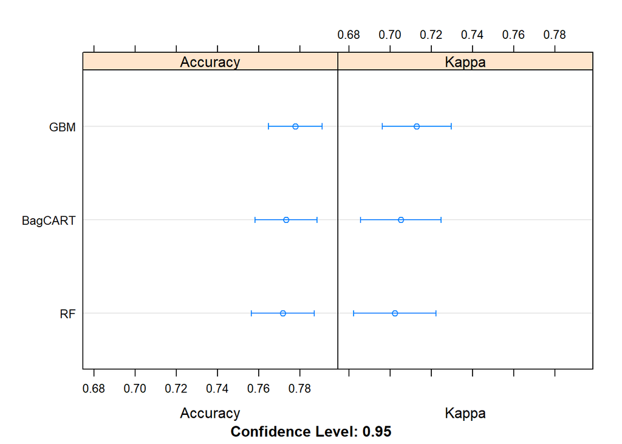

```r
dotplot(results)
```

## 6. Finalize Model and Present Results

Once we have narrow down to a model that we believe can make accurate predictions on unseen data, we are ready to finalize it. Finalizing a model may involve sub-tasks such as:

- Using an optimal model tuned to make predictions on unseen data.
- Creating a standalone model using the tuned parameters
- Saving an optimal model to file for later use.

### 6.a) Predictions on validation dataset

```r
predictions <- predict(fit.final3, newdata=validation)
confusionMatrix(predictions, validation$targetVar)
```

```
## Confusion Matrix and Statistics
##
##           Reference
## Prediction   1   2   3   4   5   6   7
##          1  23   0   0   0   0   5   8
##          2   0  48   0   0   0   1   4
##          3   0   3 112   0   0   0   4
##          4   0   0   0  21   0   0   0
##          5   0   0   0   0  12   0   1
##          6   8   1   1   0   1  72  25
##          7  16   5   4   0   3  42 159
##
## Overall Statistics
##
##                Accuracy : 0.772
##                  95% CI : (0.7356, 0.8056)
##     No Information Rate : 0.3472
##     P-Value [Acc > NIR] : < 2.2e-16
##
##                   Kappa : 0.7026
##  Mcnemar's Test P-Value : NA
##
## Statistics by Class:
##
##                      Class: 1 Class: 2 Class: 3 Class: 4 Class: 5 Class: 6
## Sensitivity           0.48936  0.84211   0.9573  1.00000  0.75000   0.6000
## Specificity           0.97556  0.99042   0.9848  1.00000  0.99822   0.9216
## Pos Pred Value        0.63889  0.90566   0.9412  1.00000  0.92308   0.6667
## Neg Pred Value        0.95580  0.98289   0.9891  1.00000  0.99293   0.8981
## Prevalence            0.08117  0.09845   0.2021  0.03627  0.02763   0.2073
## Detection Rate        0.03972  0.08290   0.1934  0.03627  0.02073   0.1244
## Detection Prevalence  0.06218  0.09154   0.2055  0.03627  0.02245   0.1865
## Balanced Accuracy     0.73246  0.91626   0.9711  1.00000  0.87411   0.7608
##                      Class: 7
## Sensitivity            0.7910
## Specificity            0.8148
## Pos Pred Value         0.6943
## Neg Pred Value         0.8800
## Prevalence             0.3472
## Detection Rate         0.2746
## Detection Prevalence   0.3955
## Balanced Accuracy      0.8029
```

### 6.b) Create standalone model on entire training dataset

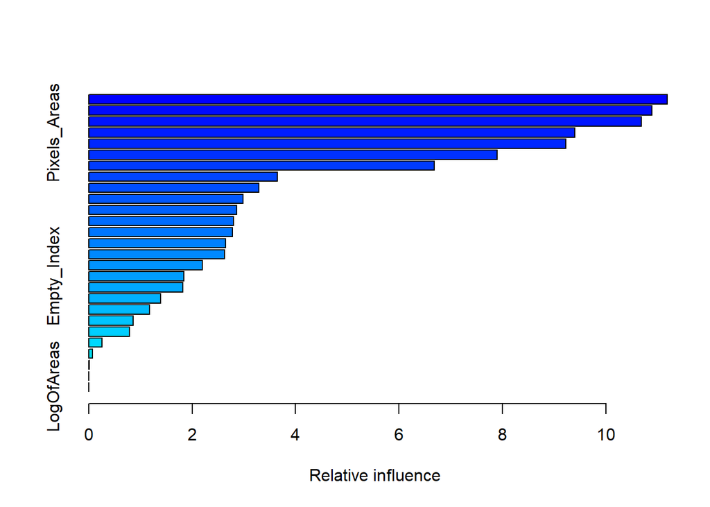

```
##                                         var      rel.inf
## Log_X_Index                     Log_X_Index 11.185562641
## Length_of_Conveyer       Length_of_Conveyer 10.892920551
## Outside_X_Index             Outside_X_Index 10.687481066
## Pixels_Areas                   Pixels_Areas  9.394482134
## Steel_Plate_Thickness Steel_Plate_Thickness  9.222588380
## TypeOfSteel_A300           TypeOfSteel_A300  7.901084463
## Orientation_Index         Orientation_Index  6.684703781
## X_Minimum                         X_Minimum  3.652485533
## Square_Index                   Square_Index  3.285549841
## Minimum_of_Luminosity Minimum_of_Luminosity  2.980956653
## Edges_Index                     Edges_Index  2.858098281
## Luminosity_Index           Luminosity_Index  2.800021816
## X_Maximum                         X_Maximum  2.779359983
## TypeOfSteel_A400           TypeOfSteel_A400  2.648250572
## Y_Minimum                         Y_Minimum  2.630102787
## Edges_Y_Index                 Edges_Y_Index  2.194507942
## Empty_Index                     Empty_Index  1.840689235
## Maximum_of_Luminosity Maximum_of_Luminosity  1.824238423
## Sum_of_Luminosity         Sum_of_Luminosity  1.387906950
## Y_Perimeter                     Y_Perimeter  1.172544204
## Edges_X_Index                 Edges_X_Index  0.856294253
## Log_Y_Index                     Log_Y_Index  0.783409014
## X_Perimeter                     X_Perimeter  0.254453761
## Y_Maximum                         Y_Maximum  0.069591684
## Outside_Global_Index   Outside_Global_Index  0.009140560
## SigmoidOfAreas               SigmoidOfAreas  0.003575491
## LogOfAreas                       LogOfAreas  0.000000000
```

```r
startTimeModule <- proc.time()
set.seed(seedNum)
grid <- expand.grid(.n.trees=500, .interaction.depth=2, .shrinkage=0.05, .n.minobsinnode=15)
finalModel <- train(targetVar~., data=entireDataset, method="gbm", metric=metricTarget, tuneGrid=grid, trControl=control, verbose=F)
summary(finalModel)
```

```r
proc.time()-startTimeModule
```

```
##    user  system elapsed
##  183.61    1.54  186.37
```

### 6.c) Save model for later use

```r
#saveRDS(finalModel, "./finalModel_MultiClass.rds")
```

```r
proc.time()-startTimeScript
```

```
##    user  system elapsed
## 4032.29   63.93 4146.81
```